# Check Raw Data

Patricka Williams-Simon and Elizabeth King

4/19/2018

## Read in Data

There are three files. The raw data for Thermal Tolerance, the raw data for Learning and Memory, and the Learning and Memory data processed through HeatCalc.

```r
#raw learning and memory data
#named LearnMem
load(file="../ProcessedData/Learn_raw.rda")


#learning and memory data processed through HeatCalc
LM_proc <- read.table(file="../ProcessedData/HeatProc_Learn.txt", sep="\t", header=TRUE, stringsAsFactors = FALSE)


#raw thermal tolerance data
#Named ThermTol
load(file="../ProcessedData/Incapacitation.rda")
```

## Assign chamber and group number to processed data

Group numbers were assigned inconsistently and so we need to merge these to track a sample through all phenotypes (& processed and raw). Patricka always numbered her groups sequentially and before James’s. Therefore, James’s were numbered starting following Patricka’s groups. There are also a few errors that get fixed here in group assignment.

```r
LearnMem[which(LearnMem$patRIL==12127 & LearnMem$group==12),'group'] <- 1

LearnMem[which(LearnMem$patRIL==12127 & LearnMem$group==12),'file'] <- "Group 1.asc"


LM_proc$chamber <- LM_proc$chamber+1
LM_proc[which(LM_proc$patRIL==11019 & LM_proc$file=="5-2.hbx"),'file']<-"5.hbx"
LM_proc[which(LM_proc$patRIL==11097 & LM_proc$file=="2-2.hbx"),'file']<-"2.hbx"
LM_proc[which(LM_proc$patRIL==11104 & LM_proc$file=="4-1.hbx"),'file']<-"4.hbx"
LM_proc[which(LM_proc$patRIL==11138 & LM_proc$file=="Group5.hbx"),'file']<-"5.hbx"

LM_proc <- LM_proc[-which(LM_proc$patRIL==11040 & LM_proc$file=="11040_001A_6min.hbx"),]

rrs<-unique(LM_proc$patRIL)

LM_procg<-LM_proc[0,]
LM_procg$group <-numeric(0)
for(rr in rrs)
{
  ss.test <- subset(LM_proc, patRIL==rr)

  gg.s <-unlist(lapply(strsplit(ss.test$file, split=".", fixed=TRUE),function(x) x[1]))
  gg.num <- rep(NA, length(gg.s))
  nn <- nchar(gg.s)
  if(all(nn>2))
  {
    uus<-unique(gg.s)
    tts<-seq(1,length(uus))
    for(i in 1:length(uus))
    {
      gg.num[gg.s==uus[i]]<-tts[i]
    }
  }else{
    if(any(nn>2))
    {
      gg.num[nn<=2]<-as.numeric(gg.s[nn<=2])
      uus<-unique(gg.s[nn>2])
      tts<-seq((max(gg.num,na.rm=T)+1),(max(gg.num,na.rm=T)+length(uus)))
      for(i in 1:length(uus))
      {
        gg.num[gg.s==uus[i]]<-tts[i]
      }

    }else{
      gg.num<-as.numeric(gg.s)
    }
  }
  ss.test$group<-gg.num
  LM_procg<-rbind(LM_procg,ss.test)
  #cat(rr,"\n")
}

wset <- which(as.numeric(ThermTol$group)>19)
ThermTol$group[wset] <- substr(ThermTol$group[wset], 1, nchar(ThermTol$group[wset])-1)

wset <- which(as.numeric(LearnMem$group)>19)
LearnMem$group[wset] <- substr(LearnMem$group[wset], 1, nchar(LearnMem$group[wset])-1)


ThermTol$group <- as.numeric(ThermTol$group)
LearnMem$group <- as.numeric(LearnMem$group)

#check for duplicates

aa <- which(duplicated(ThermTol[,1:17], MARGIN=1))
bb <- which(duplicated(ThermTol[,1:17], MARGIN=1,fromLast=TRUE))

uu.therm<-unique(ThermTol[c(aa,bb),'patRIL'])

table(ThermTol[c(aa,bb),c('patRIL','group')])
```

```
##        group
## patRIL  1 2 3 4 5 6 7 8
##   11073 0 0 0 0 0 1 1 0
##   11110 0 0 0 0 0 1 2 1
##   12033 1 2 2 2 2 2 1 0
##   12038 1 2 2 2 2 2 1 0
##   12120 1 2 2 2 2 2 1 0
```

```r
aa <- which(duplicated(LM_procg[,1:5], MARGIN=1))
bb <- which(duplicated(LM_procg[,1:5], MARGIN=1,fromLast=TRUE))

uu.LM<-unique(LM_procg[c(aa,bb),'patRIL'])

table(LM_procg[c(aa,bb),c('patRIL','group')])
```

```
##        group
## patRIL  1 2 3 4 5 6 7 8 9
##   11076 0 0 0 0 1 1 0 0 0
##   11097 0 0 0 0 1 0 0 0 1
##   11103 0 0 1 0 1 0 0 0 0
##   11105 0 0 0 0 1 1 0 0 0
##   11162 1 0 0 0 0 1 1 0 1
##   11211 0 0 0 0 1 1 0 0 0
##   11298 1 1 0 0 0 0 0 0 0
##   11420 1 0 0 0 0 1 0 0 0
##   11460 0 0 0 1 0 1 0 0 0
##   12109 0 0 1 1 0 0 0 0 0
##   12132 0 0 1 0 1 0 0 0 0
##   12207 0 0 0 1 0 0 0 1 0
##   12346 0 1 0 0 0 1 0 0 0
```

```r
aa <- which(duplicated(LearnMem[,1:7], MARGIN=1))
bb <- which(duplicated(LearnMem[,1:7], MARGIN=1,fromLast=TRUE))
uu.LMR<-unique(LearnMem[c(aa,bb),'patRIL'])

table(LearnMem[c(aa,bb),c('patRIL','group')])
```

```
##        group
## patRIL  1 2 3 4 5 6 7 8 9 10 11 12 14 16
##   11018 0 0 0 0 1 1 0 0 0  1  0  1  0  0
##   11033 0 0 0 0 0 0 0 1 0  0  0  1  0  0
##   11049 0 0 0 0 0 0 2 0 1  0  1  0  0  0
##   11073 0 0 0 0 0 1 1 0 0  0  0  0  0  0
##   11077 1 0 0 0 0 0 1 0 0  0  0  0  0  0
##   11083 0 0 0 0 0 0 0 0 0  0  0  0  1  1
##   11110 0 0 0 0 0 1 1 0 0  0  0  0  0  0
##   11334 0 0 1 0 1 0 0 0 0  0  0  0  0  0
##   11438 0 0 1 0 0 1 0 0 0  0  0  0  0  0
##   11452 0 0 1 0 0 0 1 0 0  0  0  0  0  0
##   11456 1 0 0 0 0 0 1 0 0  0  0  0  0  0
##   12033 1 0 0 0 2 0 1 0 0  0  0  0  0  0
##   12038 0 0 1 2 2 2 1 0 0  0  0  0  0  0
##   12117 0 0 0 0 1 0 2 1 0  0  0  0  0  0
##   12120 1 2 0 2 1 0 0 0 0  0  0  0  0  0
##   12149 1 0 0 0 0 1 0 0 0  0  0  0  0  0
##   12152 0 0 1 0 0 0 0 0 1  0  0  0  0  0
##   12317 0 1 0 1 0 0 0 0 0  0  0  0  0  0
##   12331 0 0 1 0 0 0 1 0 0  0  0  0  0  0
```

## Identify chambers with temperature issues

```r
#max average absolute difference between set and actual for Learning and Mem
topdif<-5

# lowest allowable average temp across the chamber during training for Thermal Tolerance
lowtem<-35

notgood <- which(ThermTol$actual.Temp.train.A < lowtem |ThermTol$actual.Temp.train.B < lowtem | ThermTol$incapacitation==0)
ThermTol.keep <- ThermTol[-notgood,]
#which chambers?


#Learn Mem
ww <- which(LearnMem$diff.train.A >= topdif|LearnMem$diff.train.B >= topdif)
LearnMem.good<-LearnMem[-ww,]

#Bring all data together
all.dat <- merge(LearnMem,ThermTol,by=c('patRIL','chamber','group'),all=TRUE)

#add a flag column for failure criteria
pL <- which(all.dat$diff.train.A >= topdif|all.dat$diff.train.B >= topdif)
pT <- which(all.dat$actual.Temp.train.A < lowtem |all.dat$actual.Temp.train.B < lowtem)
pB <- which((all.dat$actual.Temp.train.A < lowtem |all.dat$actual.Temp.train.B < lowtem) & (all.dat$diff.train.A >= topdif|all.dat$diff.train.B >= topdif))

all.dat$flag <- rep('none',nrow(all.dat))
all.dat$flag[pL] <- 'LearnFail'
all.dat$flag[pT] <- 'ThermFail'
all.dat$flag[pB] <- 'BothFail'

#merge with processed data
total.set <- merge(all.dat,LM_procg,by=c('patRIL','chamber','group'),all=TRUE)

temp <- subset(total.set, flag=='LearnFail')
temp <- temp[-which(is.na(temp$actual.Temp.test.A)),]
temp <- temp[-which(is.na(temp$Learning)),]

temp1 <- subset(total.set, flag=='ThermFail')
temp1 <- temp1[-which(is.na(temp1$diff.train.A)),]
temp1 <- temp1[-which(is.na(temp1$Learning)),]

#add flag for those that stop moving on punishment side
pA <- which(total.set$ThermAct==0 & total.set$Memory== -1)
total.set$dflag <- rep('none', nrow(total.set))
total.set$dflag[pA] <- 'dead'
```

## Visualization of the Temperature Issue

We can examine the distributions for the temperature data here.

```r
p1 <- ggplot(total.set, aes(diff.test.A)) +
  geom_histogram()
p2 <- ggplot(total.set, aes(diff.test.B)) +
  geom_histogram()
p3 <- ggplot(total.set, aes(diff.train.A)) +
  geom_histogram()
p4 <- ggplot(total.set, aes(diff.train.B)) +
  geom_histogram()

lm1 <- plot_grid(p1, p2, p3, p4, ncol=2)

cat('Learning and Memory Raw Data',"\n")
```

```
## Learning and Memory Raw Data
```

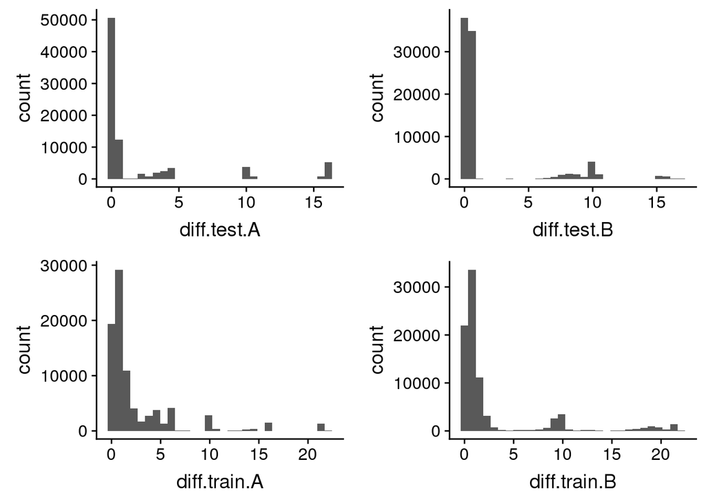

```r
lm1
```

```r
total.set.proc.kept <- total.set[-which(is.na(total.set$Learning)),]

p1 <- ggplot(total.set.proc.kept, aes(diff.test.A)) +
  geom_histogram()
p2 <- ggplot(total.set.proc.kept, aes(diff.test.B)) +
  geom_histogram()
p3 <- ggplot(total.set.proc.kept, aes(diff.train.A)) +
  geom_histogram()
p4 <- ggplot(total.set.proc.kept, aes(diff.train.B)) +
  geom_histogram()


lm2 <- plot_grid(p1, p2, p3, p4, ncol=2)

cat('Learning and Memory Post HeatCalc',"\n")
```

```
## Learning and Memory Post HeatCalc
```

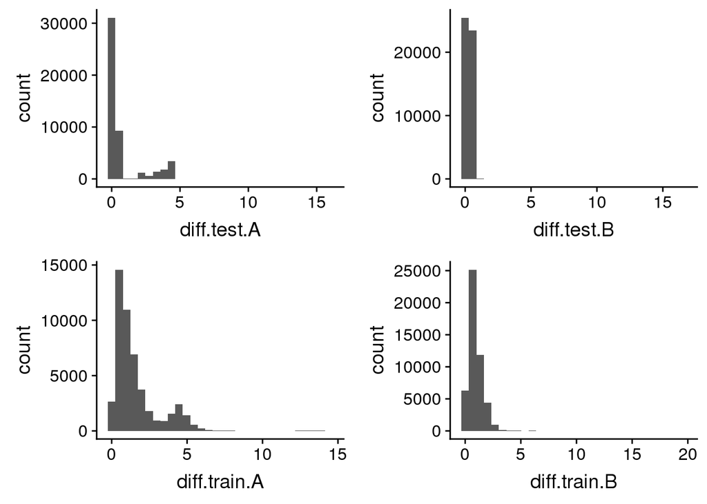

```r
lm2
```

```r
p1 <- ggplot(total.set, aes(actual.Temp.test.A)) +
  geom_histogram()
p2 <- ggplot(total.set, aes(actual.Temp.test.B)) +
  geom_histogram()
p3 <- ggplot(total.set, aes(actual.Temp.train.A)) +
  geom_histogram()
p4 <- ggplot(total.set, aes(actual.Temp.train.B)) +
  geom_histogram()

tt1 <- plot_grid(p1, p2, p3, p4, ncol=2)
cat('Thermal Tolerance',"\n")
```

```
## Thermal Tolerance
```

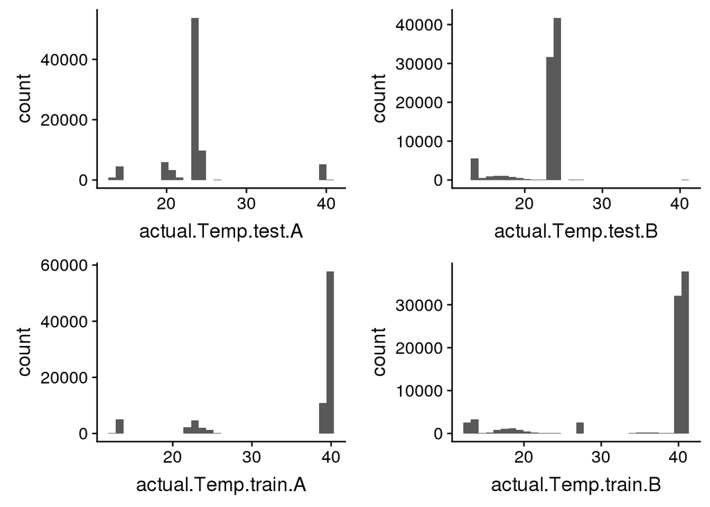

```r
tt1
```

```r
p1 <- ggplot(total.set[total.set$flag=='BothFail',], aes(actual.Temp.train.A)) +
  geom_histogram()
p2 <- ggplot(total.set[total.set$flag=='BothFail',], aes(actual.Temp.train.B)) +
  geom_histogram()
p3 <- ggplot(total.set[total.set$flag=='BothFail',], aes(diff.train.A)) +
  geom_histogram()
p4 <- ggplot(total.set[total.set$flag=='BothFail',], aes(diff.train.B)) +
  geom_histogram()

bothF <- plot_grid(p1, p2, p3, p4, ncol=2)
cat('Fail Both Criteria',"\n")
```

```
## Fail Both Criteria
```

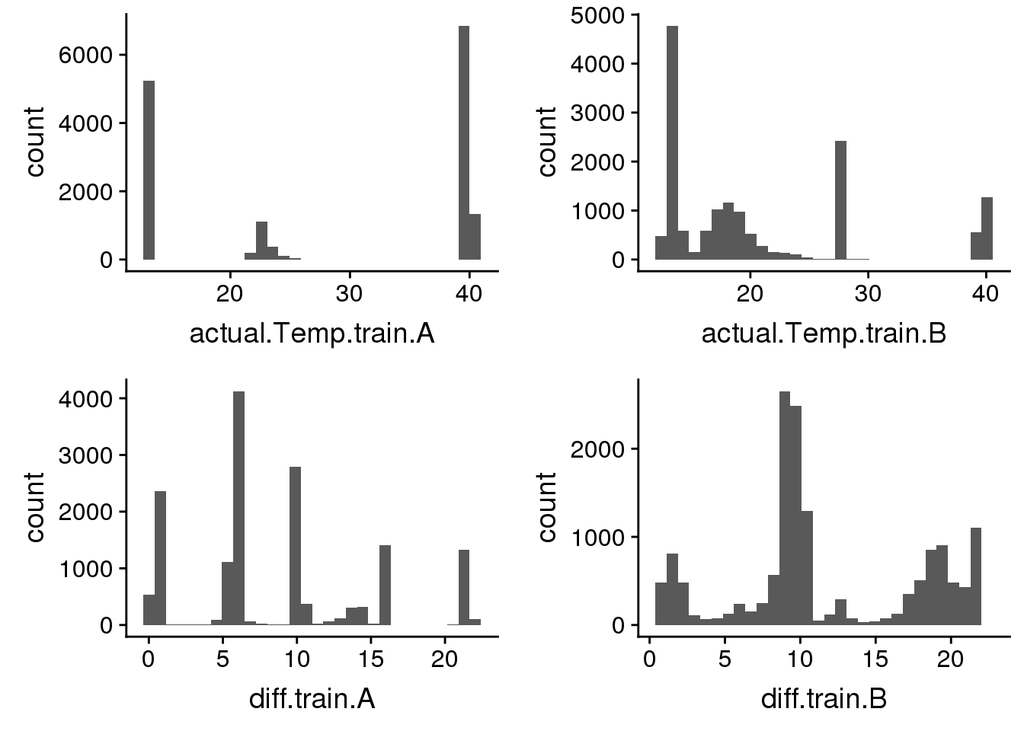

```r
bothF
```

```r
p1 <- ggplot(total.set[total.set$flag=='ThermFail',], aes(actual.Temp.train.A)) +
  geom_histogram()
p2 <- ggplot(total.set[total.set$flag=='ThermFail',], aes(actual.Temp.train.B)) +
  geom_histogram()
p3 <- ggplot(total.set[total.set$flag=='ThermFail',], aes(diff.train.A)) +
  geom_histogram()
p4 <- ggplot(total.set[total.set$flag=='ThermFail',], aes(diff.train.B)) +
  geom_histogram()

ThF <- plot_grid(p1, p2, p3, p4, ncol=2)
cat('Fail Thermal Tolerance Criteria',"\n")
```

```
## Fail Thermal Tolerance Criteria
```

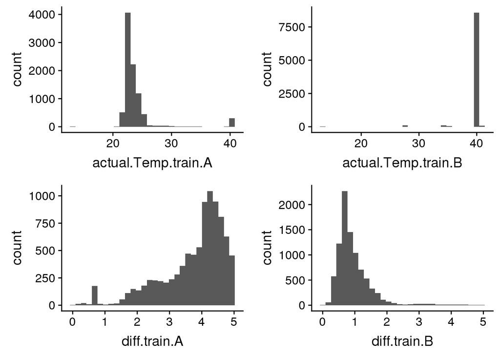

```r
ThF
```

```r
p1 <- ggplot(total.set[total.set$flag=='LearnFail',], aes(actual.Temp.train.A)) +
  geom_histogram()
p2 <- ggplot(total.set[total.set$flag=='LearnFail',], aes(actual.Temp.train.B)) +
  geom_histogram()
p3 <- ggplot(total.set[total.set$flag=='LearnFail',], aes(diff.train.A)) +
  geom_histogram()
p4 <- ggplot(total.set[total.set$flag=='LearnFail',], aes(diff.train.B)) +
  geom_histogram()

LF <- plot_grid(p1, p2, p3, p4, ncol=2)
cat('Fail Learning Criteria',"\n")
```

```
## Fail Learning Criteria
```

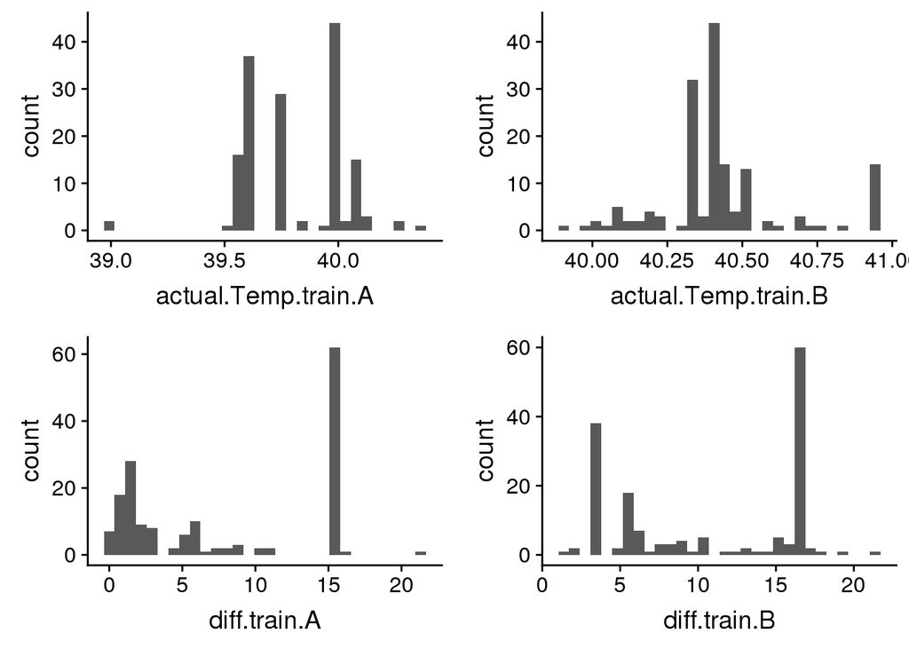

```r
LF
```

## Explore cases where activity ceases for an individual before the end of the trial

```r
#Select cases where there is  no activity for thermal tolerance but are learning records
act.ss <-which(total.set$ThermAct==0 & is.na(total.set$Learning)==FALSE)
act.ss <- total.set[act.ss,]

cat('Number in each chamber:')
```

```
## Number in each chamber:
```

```r
table(act.ss$chamber)
```

```
##
##   1   2   3   5   6   7   8   9  10  11  12  13  14  15  16
##  30   1  13  45  23  23   3  60  13  53 506   9 185  26   3
```

```r
cat('Most do not become active again after a period of no activity')
```

```
## Most do not become active again after a period of no activity
```

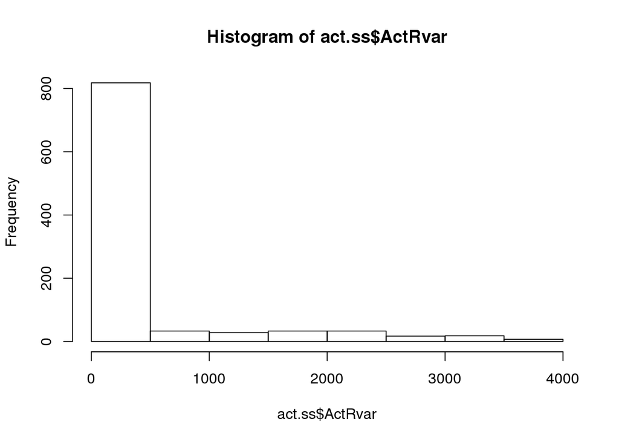

```r
hist(act.ss$ActRvar)
```

```r
cat('Distribution of Memory scores for these records')
```

```
## Distribution of Memory scores for these records
```

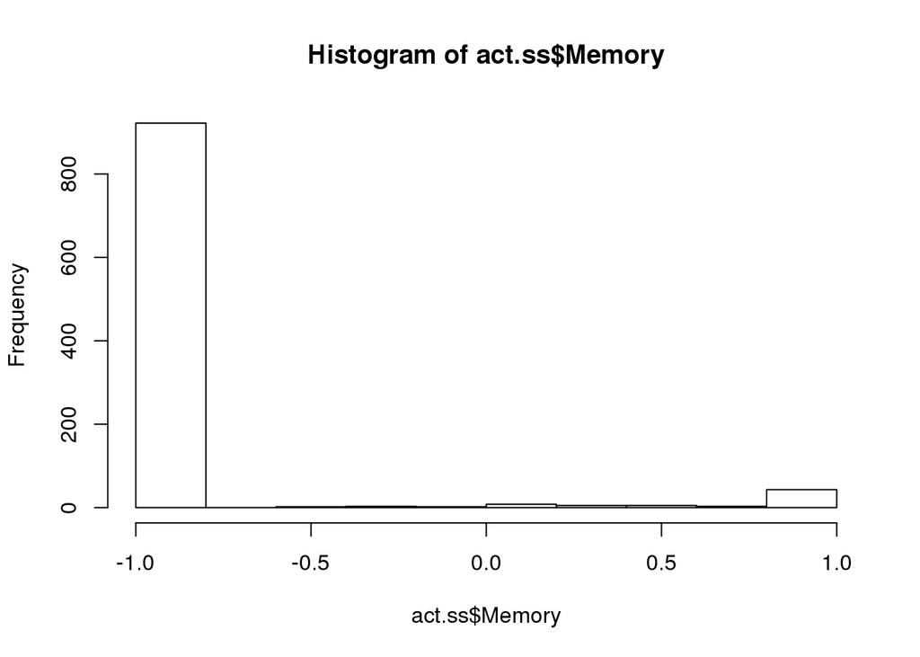

```r
hist(act.ss$Memory)
```

```r
cat('Distribution of Memory scores for all data')
```

```
## Distribution of Memory scores for all data
```

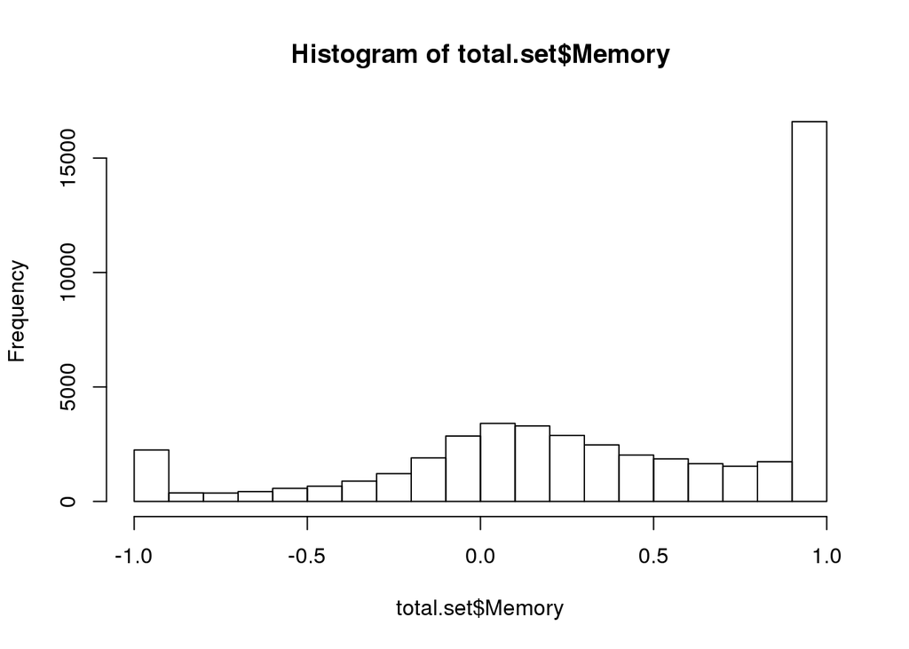

```r
hist(total.set$Memory)
```

```r
tester_mem<-subset(act.ss, Memory > -0.9 & Memory < 0.9)
#memory scores between -0.9 and 0.9
tester_mem[1:10, 1:3]
```

```
##       patRIL chamber group
## 12066  11097       9     2
## 14224  11118      11     4
## 14336  11119      14     2
## 14705  11122      14     5
## 18045  11154      12     5
## 18523  11158       2     8
## 18629  11158      10     2
## 18635  11158      10     8
## 18658  11158      12     3
## 25604  11228      11     3
```

```r
#high activty
tester_active<-subset(act.ss, ActRvar>1000 & ActStop>2e5)
tester_active[1:10, 1:3]
```

```
##       patRIL chamber group
## 25608  11228      12     1
## 25621  11228      14     2
## 25622  11228      14     3
## 28301  11259      11     2
## 70272  12231      11     3
## 76303  12302      12     7
## 76313  12302      14     3
## 76316  12302      14     6
## NA      <NA>      NA    NA
## NA.1    <NA>      NA    NA
```

```r
#low activity
tester_lowactive<-subset(act.ss, ActRvar<10 & ActStop<1e5)
tester_lowactive[1:10, 1:3]
```

```
##      patRIL chamber group
## 81    11002      12     4
## 714   11006       5     2
## 911   11008      14     1
## 1204  11011      12     2
## 1357  11013       5     5
## 1390  11013      11     2
## 1394  11013      11     6
## 1398  11013      12     4
## 1399  11013      12     5
## 1583  11014      14     3
```

Most of the cases where there is no activity in thermal tolerance but there is a learning & memory score occur in chambers 12 and 14, indicating a possible issue specific to those chambers. In the majority of cases, activty stops early and does not resume causing memory scores of 1 or -1, most often -1.

## Filtering

Here we filter out bad records. We have filtered out any that fail the thermal tolerance criteria for thermal tolerance and any that fail FOR ANY REASON for the learning data. The numbers of RILs we remain with are shown here.

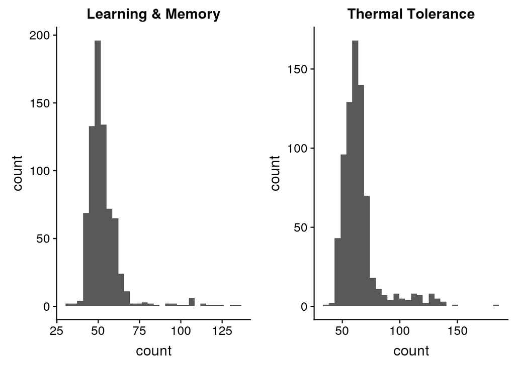

```r
LL.set <- subset(total.set, flag == 'none' & dflag == 'none')
cut.s <- which(is.na(LL.set$Learning))
LL.set <- LL.set[-cut.s,]

LL.count <-as.data.frame(table(LL.set$patRIL))
colnames(LL.count) <- c('patRIL','count')
checkL <- LL.count[which(LL.count$count<55),]

TT.count <-as.data.frame(table(ThermTol.keep$patRIL))
colnames(TT.count) <- c('patRIL','count')

checkR <- TT.count[which(TT.count$count<55),]

p1 <- ggplot(LL.count, aes(count)) +
  geom_histogram() +
  ggtitle("Learning & Memory")

p2 <- ggplot(TT.count, aes(count)) +
  geom_histogram() +
  ggtitle("Thermal Tolerance")

plot_grid(p1, p2, ncol=2)
```

### Thermal Tolerance:

The lowest count is 36.

307 RILs have fewer than 60.

174 RILs have fewer than 55.

64 RILs have fewer than 50.

1 RILs have fewer than 40.

### Learning & Memory:

The lowest count is 31.

630 RILs have fewer than 60.

515 RILs have fewer than 55.

315 RILs have fewer than 50.

4 RILs have fewer than 40.

Some final checking:

```r
TT.count$patRIL[which(!(TT.count$patRIL %in% LL.count$patRIL))]
```

```
## factor(0)
## 741 Levels: 11002 11003 11004 11005 11006 11008 11009 11010 11011 ... 12395
```

```r
LL.count$patRIL[which(!(LL.count$patRIL %in% TT.count$patRIL))]
```

```
## factor(0)
## 741 Levels: 11002 11003 11004 11005 11006 11008 11009 11010 11011 ... 12395
```

```r
total.set.proc.kept <- total.set[-which(is.na(total.set$Learning)),]

raw.proc.learn.rils <- unique(total.set.proc.kept[which(is.na(total.set.proc.kept$diff.train.A)),'patRIL'])

for(rr in raw.proc.learn.rils)
{
  set.temp <- subset(total.set, patRIL==rr)
  cat(rr,"\n","groups:", sort(unique(set.temp$group)),"\n",
      "learn files:", sort(unique(set.temp$file.x)), "\n",
      "therm files:", sort(unique(set.temp$file.y)), "\n",
      "learn heat calc files:", sort(unique(set.temp$file)),"\n","\n")


}

raw.proc.therm.rils <- unique(total.set[which(is.na(total.set$incapacitation)),'patRIL'])

for(rr in raw.proc.therm.rils)
{
  set.temp <- subset(total.set, patRIL==rr)
  cat(rr,"\n","groups:", sort(unique(set.temp$group)),"\n",
      "learn files:", sort(unique(set.temp$file.x)), "\n",
      "therm files:", sort(unique(set.temp$file.y)), "\n",
      "learn heat calc files:", sort(unique(set.temp$file)),"\n","\n")


}
```

## Write out final files

```r
write.table(ThermTol.keep,file= "../ProcessedData/ThermalTol_processed.txt",row.names=FALSE,sep="\t")

write.table(LL.set,file= "../ProcessedData/LearnMem_processed.txt",row.names=FALSE,sep="\t")
```